# Titanic Survival Analysis - Gender, SES, and Mediators

Author

CLI Copilot

## EDA

```r
# Structure and missingness
skim_summary <- tibble(
  n = nrow(train),
  missing_age = sum(is.na(train$age)),
  missing_embarked = sum(is.na(train$embarked)),
  missing_cabin = sum(is.na(train$cabin))
)
skim_summary
```

```
# A tibble: 1 × 4
      n missing_age missing_embarked missing_cabin
  <int>       <int>            <int>         <int>
1   891         177                2           687
```

```r
train %>% count(sex, pclass, survived) %>%
  mutate(prop = n/sum(n)) %>% arrange(desc(prop)) %>% kable()
```

| sex | pclass | survived | n | prop |
| --- | --- | --- | --- | --- |
| male | 3rd | 0 | 300 | 0.3367003 |
| female | 1st | 1 | 91 | 0.1021324 |
| male | 2nd | 0 | 91 | 0.1021324 |
| male | 1st | 0 | 77 | 0.0864198 |
| female | 3rd | 0 | 72 | 0.0808081 |
| female | 3rd | 1 | 72 | 0.0808081 |
| female | 2nd | 1 | 70 | 0.0785634 |
| male | 3rd | 1 | 47 | 0.0527497 |
| male | 1st | 1 | 45 | 0.0505051 |
| male | 2nd | 1 | 17 | 0.0190797 |
| female | 2nd | 0 | 6 | 0.0067340 |
| female | 1st | 0 | 3 | 0.0033670 |

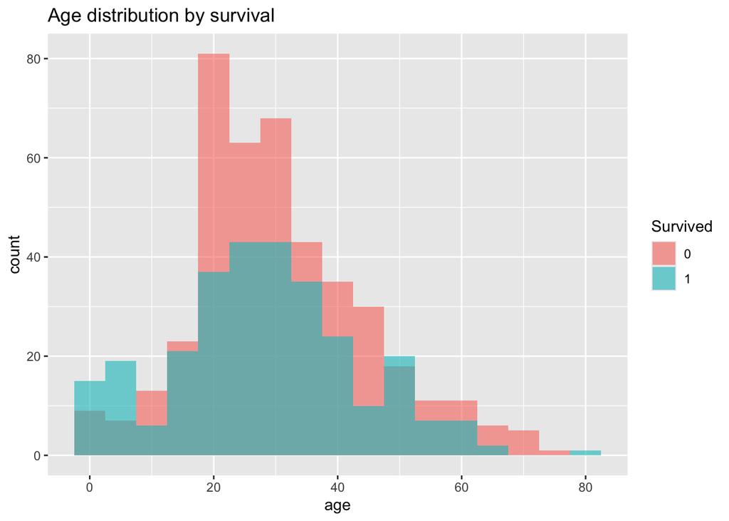

```r
train %>% ggplot(aes(x = age, fill = factor(survived))) +
  geom_histogram(binwidth = 5, position = "identity", alpha = 0.6) +
  labs(fill = "Survived", title = "Age distribution by survival")
```

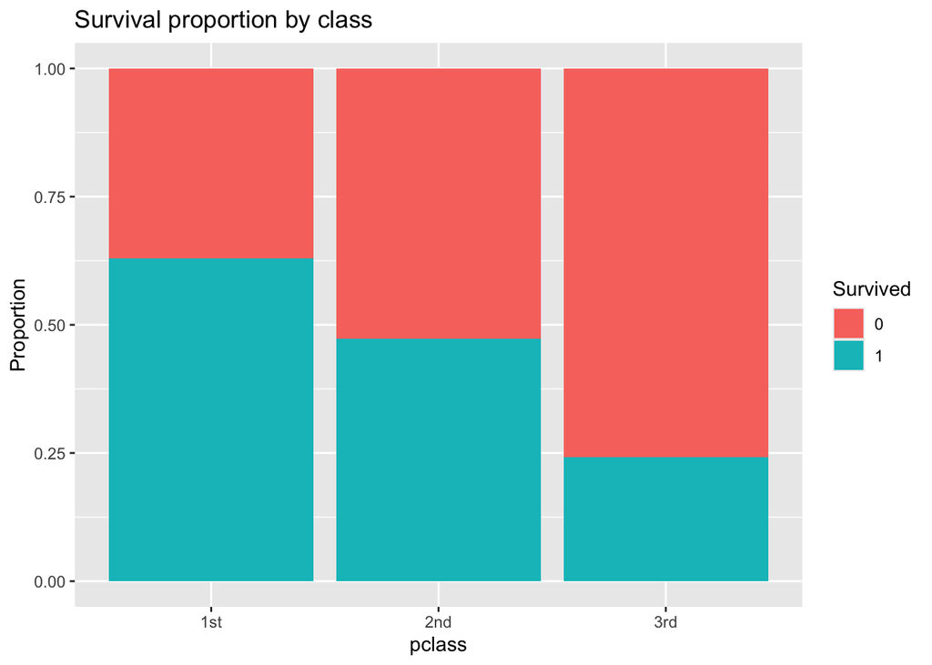

```r
train %>% ggplot(aes(x = pclass, fill = factor(survived))) +
  geom_bar(position = "fill") +
  labs(y = "Proportion", fill = "Survived", title = "Survival proportion by class")
```

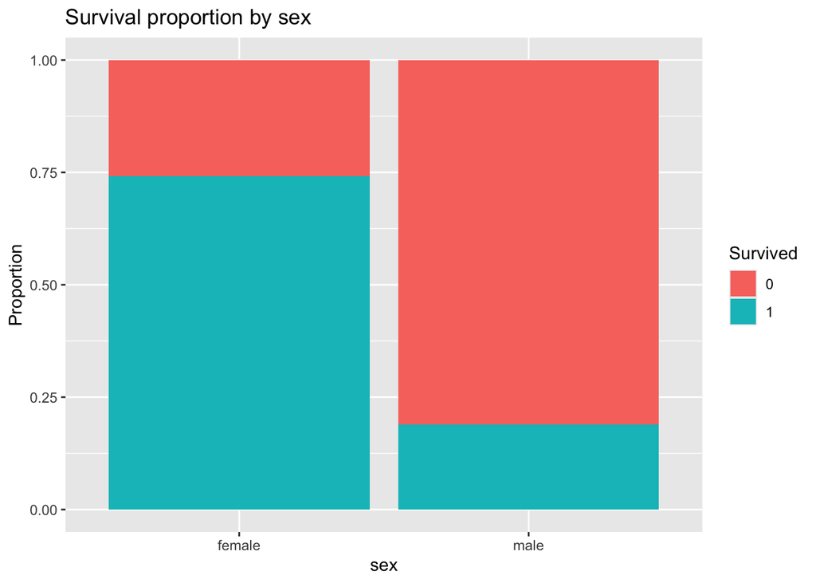

```r
train %>% ggplot(aes(x = sex, fill = factor(survived))) +
  geom_bar(position = "fill") +
  labs(y = "Proportion", fill = "Survived", title = "Survival proportion by sex")
```

## Modeling: Survival ~ Gender + SES with mediators

We fit logistic regressions to quantify joint effects of gender and SES, and assess mediation by age, family structure, and port of embarkation.

```r
# Use a consistent complete-case dataset for model comparisons
mod_data <- train %>% drop_na(survived, sex, pclass, age_group, family_structure, embarked)

# Baseline: sex + pclass + interaction
m1 <- glm(survived ~ sex * pclass, data = mod_data, family = binomial())
# Add age group
m2 <- glm(survived ~ sex * pclass + age_group, data = mod_data, family = binomial())
# Add family structure
m3 <- glm(survived ~ sex * pclass + age_group + family_structure, data = mod_data, family = binomial())
# Add port of embarkation
m4 <- glm(survived ~ sex * pclass + age_group + family_structure + embarked, data = mod_data, family = binomial())

models <- list(m1 = m1, m2 = m2, m3 = m3, m4 = m4)

bind_rows(lapply(names(models), function(nm) {
  broom::tidy(models[[nm]]) %>% mutate(model = nm)
})) %>%
  filter(term %in% c("sexmale","pclass2nd","pclass3rd","sexmale:pclass2nd","sexmale:pclass3rd")) %>%
  mutate(or = exp(estimate)) %>%
  select(model, term, estimate, std.error, p.value, or) %>%
  arrange(model, term) %>% kable(digits = 3, caption = "Key coefficients: gender, SES, and interactions")
```

Key coefficients: gender, SES, and interactions

| model | term | estimate | std.error | p.value | or |
| --- | --- | --- | --- | --- | --- |
| m1 | pclass2nd | -0.933 | 0.725 | 0.198 | 0.393 |
| m1 | pclass3rd | -3.390 | 0.610 | 0.000 | 0.034 |
| m1 | sexmale | -3.927 | 0.616 | 0.000 | 0.020 |
| m1 | sexmale:pclass2nd | -0.207 | 0.794 | 0.794 | 0.813 |
| m1 | sexmale:pclass3rd | 2.074 | 0.657 | 0.002 | 7.953 |
| m2 | pclass2nd | -1.081 | 0.731 | 0.139 | 0.339 |
| m2 | pclass3rd | -3.776 | 0.628 | 0.000 | 0.023 |
| m2 | sexmale | -3.944 | 0.621 | 0.000 | 0.019 |
| m2 | sexmale:pclass2nd | -0.373 | 0.804 | 0.642 | 0.689 |
| m2 | sexmale:pclass3rd | 2.146 | 0.665 | 0.001 | 8.553 |
| m3 | pclass2nd | -1.020 | 0.734 | 0.165 | 0.360 |
| m3 | pclass3rd | -3.789 | 0.631 | 0.000 | 0.023 |
| m3 | sexmale | -4.062 | 0.628 | 0.000 | 0.017 |
| m3 | sexmale:pclass2nd | -0.418 | 0.808 | 0.605 | 0.659 |
| m3 | sexmale:pclass3rd | 2.192 | 0.668 | 0.001 | 8.951 |
| m4 | pclass2nd | -0.854 | 0.738 | 0.247 | 0.426 |
| m4 | pclass3rd | -3.748 | 0.636 | 0.000 | 0.024 |
| m4 | sexmale | -4.014 | 0.630 | 0.000 | 0.018 |
| m4 | sexmale:pclass2nd | -0.462 | 0.809 | 0.568 | 0.630 |
| m4 | sexmale:pclass3rd | 2.204 | 0.669 | 0.001 | 9.059 |

```r
# Likelihood comparison to assess incremental contribution of mediators
anova(m1, m2, test = "Chisq")
```

```
Analysis of Deviance Table

Model 1: survived ~ sex * pclass
Model 2: survived ~ sex * pclass + age_group
  Resid. Df Resid. Dev Df Deviance  Pr(>Chi)
1       883     797.97
2       877     765.80  6   32.168 1.515e-05 ***
---
Signif. codes:  0 '***' 0.001 '**' 0.01 '*' 0.05 '.' 0.1 ' ' 1
```

```r
anova(m2, m3, test = "Chisq")
```

```
Analysis of Deviance Table

Model 1: survived ~ sex * pclass + age_group
Model 2: survived ~ sex * pclass + age_group + family_structure
  Resid. Df Resid. Dev Df Deviance Pr(>Chi)
1       877     765.80
2       874     757.47  3   8.3296  0.03967 *
---
Signif. codes:  0 '***' 0.001 '**' 0.01 '*' 0.05 '.' 0.1 ' ' 1
```

```r
anova(m3, m4, test = "Chisq")
```

```
Analysis of Deviance Table

Model 1: survived ~ sex * pclass + age_group + family_structure
Model 2: survived ~ sex * pclass + age_group + family_structure + embarked
  Resid. Df Resid. Dev Df Deviance Pr(>Chi)
1       874     757.47
2       872     749.32  2   8.1471  0.01702 *
---
Signif. codes:  0 '***' 0.001 '**' 0.01 '*' 0.05 '.' 0.1 ' ' 1
```

### Predicted probabilities across gender and SES

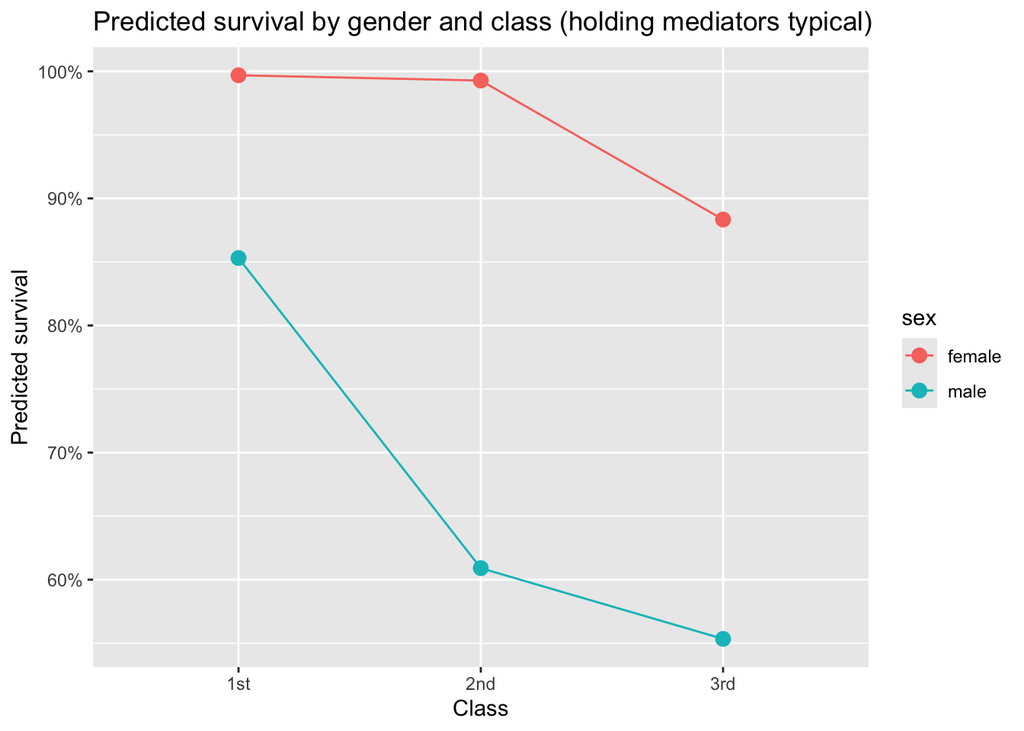

```r
newdata <- expand_grid(
  sex = factor(c("female","male"), levels = levels(train$sex)),
  pclass = factor(c("1st","2nd","3rd"), levels = levels(train$pclass)),
  age_group = factor(c("Infant","Child","Teen","YoungAdult","Adult","Senior","Unknown"), levels = levels(train$age_group)),
  family_structure = factor(levels(train$family_structure), levels = levels(train$family_structure)),
  embarked = factor(levels(train$embarked), levels = levels(train$embarked))
) %>%
  # Use most common categories for mediators for presentation
  group_by(sex, pclass) %>%
  mutate(
    age_group = fct_explicit_na(age_group, na_level = "Unknown"),
    family_structure = fct_lump_prop(family_structure, prop = 0.05),
    embarked = fct_lump_prop(embarked, prop = 0.05)
  ) %>%
  slice(1) %>% ungroup()

newdata$pred_m4 <- predict(m4, newdata = newdata, type = "response")

newdata %>% ggplot(aes(x = pclass, y = pred_m4, color = sex, group = sex)) +
  geom_point(size = 3) + geom_line() +
  scale_y_continuous(labels = scales::percent_format()) +
  labs(title = "Predicted survival by gender and class (holding mediators typical)", y = "Predicted survival", x = "Class")
```

## Age group risk

Identify which age group has the lowest predicted survival probability.

```r
# Fit a model focusing on age group effects controlling for sex and class
mage <- glm(survived ~ sex + pclass + age_group, data = train, family = binomial())
agd <- expand_grid(
  sex = factor(c("female","male"), levels = levels(train$sex)),
  pclass = factor(c("1st","2nd","3rd"), levels = levels(train$pclass)),
  age_group = levels(train$age_group)
) %>% mutate(age_group = factor(age_group, levels = levels(train$age_group)))
agd$pred <- predict(mage, newdata = agd, type = "response")

age_summary <- agd %>% group_by(age_group) %>% summarise(mean_pred = mean(pred)) %>% arrange(mean_pred)
age_summary %>% kable(digits = 3, caption = "Average predicted survival by age group (adjusted for sex and class)")
```

Average predicted survival by age group (adjusted for sex and class)

| age_group | mean_pred |
| --- | --- |
| Senior | 0.385 |
| Adult | 0.499 |
| Unknown | 0.502 |
| YoungAdult | 0.511 |
| Teen | 0.566 |
| Child | 0.574 |
| Infant | 0.780 |

```r
worst_age <- age_summary %>% slice(1)
worst_age
```

```
# A tibble: 1 × 2
  age_group mean_pred
  <fct>         <dbl>
1 Senior        0.385
```

## Recommendation to improve Titanic safety

Based on the analysis, prioritize policies that increase survival for the highest-risk groups:

- Reinforce evacuation priority and access to lifeboats for males in lower classes, especially in 3rd class.
- Improve lifeboat capacity and equitable distribution across decks to reduce class-based bottlenecks.
- Provide targeted assistance for the worst-performing age group (from the analysis output), ensuring clear signage, crew guidance, and muster drills tailored to that group.
- Standardize embarkation and muster procedures across ports to minimize variability; ensure consistent safety briefings regardless of embarkation port.